# Homework12

Angela McMahon

4/21/2026

### Loading in Three Worksheets of Penguin Data

```r
read_excel("penguins.xlsx")
```

```
## # A tibble: 52 × 8
##    species island    bill_length_mm bill_depth_mm flipper_length_mm body_mass_g
##    <chr>   <chr>     <chr>          <chr>         <chr>             <chr>
##  1 Adelie  Torgersen 39.1           18.7          181.0             3750.0
##  2 Adelie  Torgersen 39.5           17.4          186.0             3800.0
##  3 Adelie  Torgersen 40.3           18.0          195.0             3250.0
##  4 Adelie  Torgersen NA             NA            NA                NA
##  5 Adelie  Torgersen 36.7           19.3          193.0             3450.0
##  6 Adelie  Torgersen 39.3           20.6          190.0             3650.0
##  7 Adelie  Torgersen 38.9           17.8          181.0             3625.0
##  8 Adelie  Torgersen 39.2           19.6          195.0             4675.0
##  9 Adelie  Torgersen 34.1           18.1          193.0             3475.0
## 10 Adelie  Torgersen 42.0           20.2          190.0             4250.0
## # ℹ 42 more rows
## # ℹ 2 more variables: sex <chr>, year <dbl>
```

```r
t_island <- read_excel("penguins.xlsx", sheet="Torgersen Island", na="NA")
head(t_island)
```

```
## # A tibble: 6 × 8
##   species island    bill_length_mm bill_depth_mm flipper_length_mm body_mass_g
##   <chr>   <chr>              <dbl>         <dbl>             <dbl>       <dbl>
## 1 Adelie  Torgersen           39.1          18.7               181        3750
## 2 Adelie  Torgersen           39.5          17.4               186        3800
## 3 Adelie  Torgersen           40.3          18                 195        3250
## 4 Adelie  Torgersen           NA            NA                  NA          NA
## 5 Adelie  Torgersen           36.7          19.3               193        3450
## 6 Adelie  Torgersen           39.3          20.6               190        3650
## # ℹ 2 more variables: sex <chr>, year <dbl>
```

```r
b_island <- read_excel("penguins.xlsx", sheet="Biscoe Island", na="NA")
head(b_island)
```

```
## # A tibble: 6 × 8
##   species island bill_length_mm bill_depth_mm flipper_length_mm body_mass_g
##   <chr>   <chr>           <dbl>         <dbl>             <dbl>       <dbl>
## 1 Adelie  Biscoe           37.8          18.3               174        3400
## 2 Adelie  Biscoe           37.7          18.7               180        3600
## 3 Adelie  Biscoe           35.9          19.2               189        3800
## 4 Adelie  Biscoe           38.2          18.1               185        3950
## 5 Adelie  Biscoe           38.8          17.2               180        3800
## 6 Adelie  Biscoe           35.3          18.9               187        3800
## # ℹ 2 more variables: sex <chr>, year <dbl>
```

```r
d_island <- read_excel("penguins.xlsx", sheet="Dream Island", na="NA")
head(d_island)
```

```
## # A tibble: 6 × 8
##   species island bill_length_mm bill_depth_mm flipper_length_mm body_mass_g
##   <chr>   <chr>           <dbl>         <dbl>             <dbl>       <dbl>
## 1 Adelie  Dream            39.5          16.7               178        3250
## 2 Adelie  Dream            37.2          18.1               178        3900
## 3 Adelie  Dream            39.5          17.8               188        3300
## 4 Adelie  Dream            40.9          18.9               184        3900
## 5 Adelie  Dream            36.4          17                 195        3325
## 6 Adelie  Dream            39.2          21.1               196        4150
## # ℹ 2 more variables: sex <chr>, year <dbl>
```

After downloading the Penguins excel workbook, loaded in each worksheet separately. Each sheet was stored under it’s island initial. [^1]

### Stacking the Three Sheets Together

```r
comb_islands <-bind_rows(t_island, b_island, d_island)
head(comb_islands)
```

```
## # A tibble: 6 × 8
##   species island    bill_length_mm bill_depth_mm flipper_length_mm body_mass_g
##   <chr>   <chr>              <dbl>         <dbl>             <dbl>       <dbl>
## 1 Adelie  Torgersen           39.1          18.7               181        3750
## 2 Adelie  Torgersen           39.5          17.4               186        3800
## 3 Adelie  Torgersen           40.3          18                 195        3250
## 4 Adelie  Torgersen           NA            NA                  NA          NA
## 5 Adelie  Torgersen           36.7          19.3               193        3450
## 6 Adelie  Torgersen           39.3          20.6               190        3650
## # ℹ 2 more variables: sex <chr>, year <dbl>
```

To stack the three sheets, bound the rows to make the tibble longer. This was stored as comb. islands and the first few rows were displayed. [^2]

### Scatterplot: Bill Length vs. Depth (mm) by Isalnd

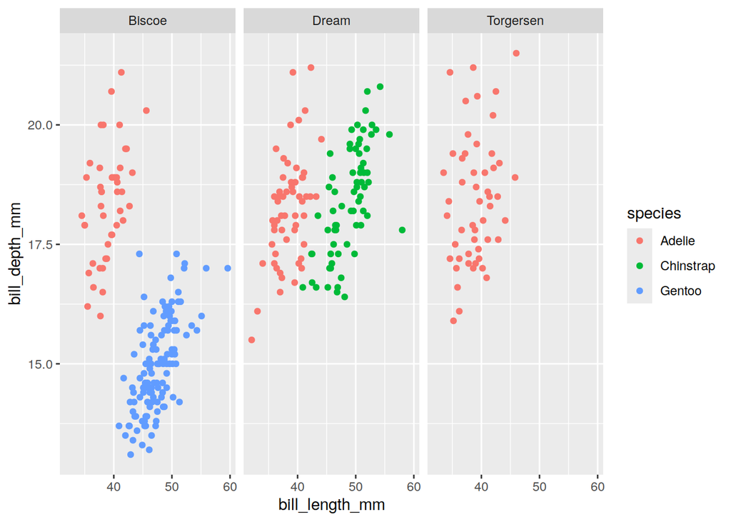

```r
ggplot(comb_islands, aes(x=bill_length_mm, y=bill_depth_mm, color=species))+
  geom_point()+
  facet_wrap(~island)
```

Using the combined stored data, make a scatterplot of bill length versus bill depth. The points are colored by species and the graph faceted by the different islands in the Palmer Archipelago. Intersting there is only Adelie in Torgersen and they are also the only species at all three islands. [^3]

### Table of Species and Average Body Mass (g)

```r
comb_islands%>%
  group_by(species)%>%
  summarize(avg_weight=mean(body_mass_g, na.rm=TRUE))%>%
  kable()
```

| species | avg_weight |
| --- | --- |
| Adelie | 3700.662 |
| Chinstrap | 3733.088 |
| Gentoo | 5076.016 |

Again using the stacked data, grouped by species. Used summarize from dplyr to create an average weight column where the mean of the body mass in g. was taken, the NAs were also removed. This was displayed in a table. [^4]

### Starting New DuckDB Database

```r
library(DBI)
library(duckdb)
con <- DBI::dbConnect(duckdb::duckdb())
```

Loaded in R interface and duckDB. Established connection to new duckdb database. [^5]

### Writing Combinded Penguins Data into DuckDB

```r
dbWriteTable(con, "comb_islands", comb_islands)
```

Writing in the combined penguin tibble from the R environment into the duckdb as a table. [^6]

### Connection of Table to Dplyr

```r
comb_islands_db<-tbl(con,"comb_islands")
comb_islands_db%>%
  collect()
```

```
## # A tibble: 344 × 8
##    species island    bill_length_mm bill_depth_mm flipper_length_mm body_mass_g
##    <chr>   <chr>              <dbl>         <dbl>             <dbl>       <dbl>
##  1 Adelie  Torgersen           39.1          18.7               181        3750
##  2 Adelie  Torgersen           39.5          17.4               186        3800
##  3 Adelie  Torgersen           40.3          18                 195        3250
##  4 Adelie  Torgersen           NA            NA                  NA          NA
##  5 Adelie  Torgersen           36.7          19.3               193        3450
##  6 Adelie  Torgersen           39.3          20.6               190        3650
##  7 Adelie  Torgersen           38.9          17.8               181        3625
##  8 Adelie  Torgersen           39.2          19.6               195        4675
##  9 Adelie  Torgersen           34.1          18.1               193        3475
## 10 Adelie  Torgersen           42            20.2               190        4250
## # ℹ 334 more rows
## # ℹ 2 more variables: sex <chr>, year <dbl>
```

Created a dbplyr reference pointing R to my table inside my database. Used collect to download that data and bring i to my local enviornment as a table. [^7]

### SQL Query: Calculating Average Body Mass for Different Species

```r
comb_islands_db%>%
  select(species, body_mass_g)%>%
  group_by(species)%>%
  summarize(avg_mass=mean(body_mass_g, na.rm=TRUE))%>%
  show_query()
```

```
## <SQL>
## SELECT species, AVG(body_mass_g) AS avg_mass
## FROM (
##   SELECT species, body_mass_g
##   FROM comb_islands
## ) q01
## GROUP BY species
```

[^1]: Question 1 completed.
[^2]: Question 2 completed.
[^3]: Question 3 completed.
[^4]: Question 4 completed.
[^5]: Question 5 completed.
[^6]: Question 6 completed.
[^7]: Question 7 completed.